# Regression Inference & Data Transformations

Dylan Maddux

2024-09-13

**A group of students at Cal Poly wanted to investigate the factors that influence house prices (Koester, Davis, and Ross, 2003). They selected a random sample of n = 83 houses for sale in three regions of California. For each house selected, they recorded the house’s price, number of square feet, number of bedrooms, and number of bathrooms.**

**Question 1** Import the data into your R session, and make a scatterplot of price (on the Y axis) versus square feet (on the X axis). Does the relationship appear to be roughly linear? Are there any apparent outliers? Use the lm function in R to fit a simple linear regression to predict price from size (square feet). Interpret the estimated slope of the regression line in context. What is the estimate of σ, the population standard deviation of the errors? How would you interpret this value? Use the R output to perform a t-test on the slope of the line and assess whether there is a “statistically significant” relationship between the price and the size of a house.

```r
library(ggplot2)
library(dplyr)
houses <- read.csv('data/Houses.csv')
head(houses)
```

```
##   Square.Feet  Price Bedrooms Baths
## 1        3392 339000        3   2.1
## 2        4100 899900        4   3.0
## 3        3200 448641        5   4.0
## 4        1436 239999        4   3.0
## 5        1944 377500        3   2.0
## 6        1500 299900        3   2.5
```

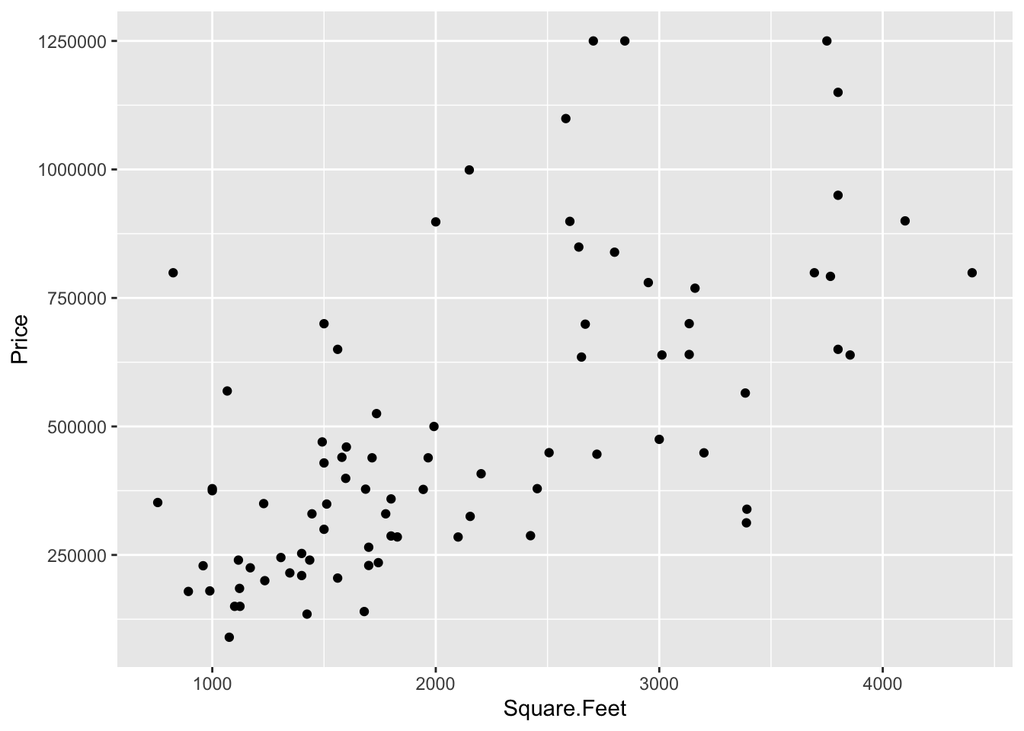

```r
ggplot(houses, aes(Square.Feet, Price)) +
  geom_point()
```

The relationship appears to be roughly linear, and there doesn’t seem to be any obvious outliers.

```r
model1 <- lm(Price~Square.Feet, houses)
summary(model1)
```

```
##
## Call:
## lm(formula = Price ~ Square.Feet, data = houses)
##
## Residuals:
##     Min      1Q  Median      3Q     Max
## -439654 -144256  -52040   97373  636508
##
## Coefficients:
##             Estimate Std. Error t value Pr(>|t|)
## (Intercept) 65930.31   60993.62   1.081    0.283
## Square.Feet   202.43      26.39   7.670 3.35e-11 ***
## ---
## Signif. codes:  0 '***' 0.001 '**' 0.01 '*' 0.05 '.' 0.1 ' ' 1
##
## Residual standard error: 222100 on 81 degrees of freedom
## Multiple R-squared:  0.4207, Adjusted R-squared:  0.4136
## F-statistic: 58.83 on 1 and 81 DF,  p-value: 3.349e-11
```

Every increase by 1 Square Foot results in an average of a $202.43 increase in house price.

The estimate of the population standard deviation of the errors is 222,100, which is how much the price tends to deviate from the fitted linear model.

The p-value of 3.35e-11 indicates a statistically significant relationship between the price and size of a house.

**Question 2** Make appropriate diagnostic plots of the residuals from the simple linear model. (We looked at these in class and discussed them briefly, so this may be review.) Do the conditions for inference on the model appear to be met? Briefly but clearly explain what features of the plots lead you to this conclusion.

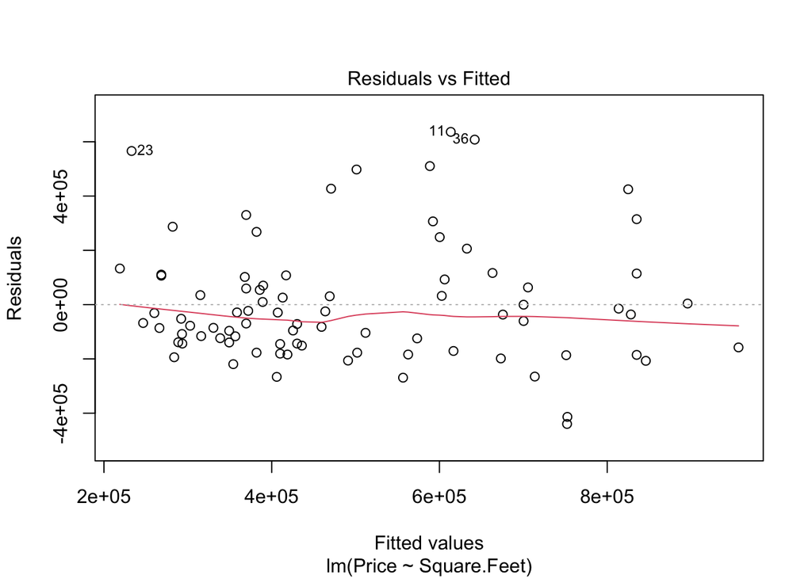

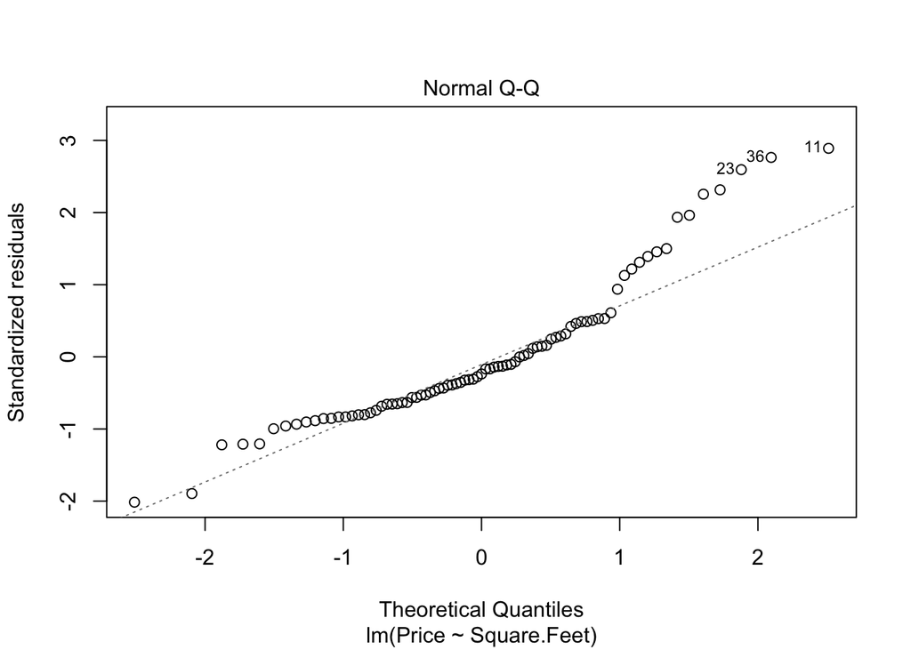

```r
plot(model1, 1:2)
```

The conditions for inference on the model are not met because the residuals display greater variance levels as the predictor variable increases while the normal quantile plot exhibits a right-skew, suggesting that the distribution does not meet the standards for normality.

**Question 3** Now fit a model to predict the logarithm of price using square feet. Can you easily interpret the slope of the regression line in this case? Give the t-statistic and p-value for testing whether there is a “statistically significant” relationship between log price and square feet. Does this differ substantively from what you found with the first model?

```r
houses = dplyr::mutate(houses, logprice = log(Price))

model2 <- lm(logprice~Square.Feet, houses)
summary(model2)
```

```
##
## Call:
## lm(formula = logprice ~ Square.Feet, data = houses)
##
## Residuals:
##      Min       1Q   Median       3Q      Max
## -1.08988 -0.29591 -0.05899  0.28717  1.20206
##
## Coefficients:
##              Estimate Std. Error t value Pr(>|t|)
## (Intercept) 1.204e+01  1.236e-01   97.36  < 2e-16 ***
## Square.Feet 4.274e-04  5.349e-05    7.99 7.87e-12 ***
## ---
## Signif. codes:  0 '***' 0.001 '**' 0.01 '*' 0.05 '.' 0.1 ' ' 1
##
## Residual standard error: 0.4502 on 81 degrees of freedom
## Multiple R-squared:  0.4407, Adjusted R-squared:  0.4338
## F-statistic: 63.83 on 1 and 81 DF,  p-value: 7.874e-12
```

In this case, it is harder to interpret the slope of the regression line.

No, this does not differ substantively from what I found with the first model since the p-value and t-statistic are very similar.

**Question 4** Make the appropriate diagnostic plots of the residuals, and comment on the conditions for inference with this model.

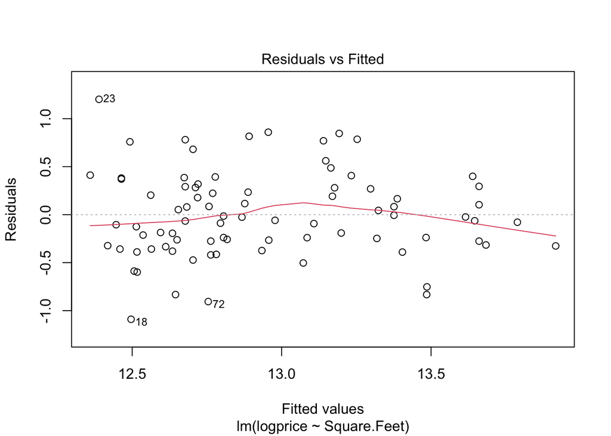

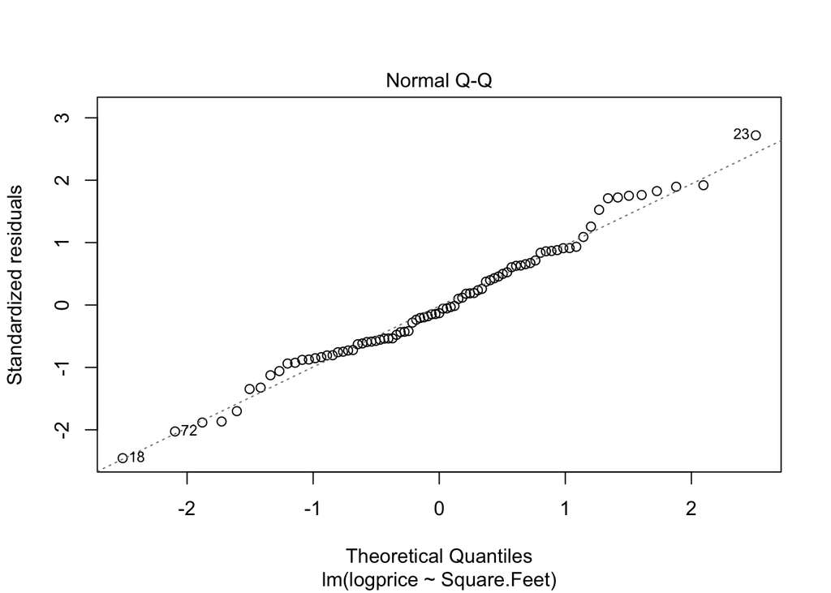

```r
plot(model2, 1:2)
```

Although this model is better in that the data appears more normally distributed with the Q-Q plot appearing relatively normal, the variance decreases as the predictor variables increases, meaning it may not meet the conditions for inference.

**Question 5** Suppose that your Uncle Bob has an 1800 square foot house in one of the regions in California that was sampled by the students. First, use your untransformed model to make a 95% prediction interval for the sale price of Uncle Bob’s house. Interpret your interval.

```r
UncleBob = data.frame(Square.Feet=c(1800))
      predict(model1, newdata=UncleBob, se.fit=T, interval="prediction")
```

```
## $fit
##        fit       lwr    upr
## 1 430296.7 -14655.54 875249
##
## $se.fit
## [1] 25789.48
##
## $df
## [1] 81
##
## $residual.scale
## [1] 222137.3
```

The 95% prediction interval in this case is between -$14,655.55 and $875,249, meaning that there is a 95% probability that an 1800 square foot house would be sold for between -14,655.55 and 875,249 dollars. In this case, the interval doesn’t make sense and isn’t useful since the range is enormous and a house cannot cost negative dollars.

**Question 6** Use your untransformed model to make a 95% confidence interval for the mean sale price of all 1800 square foot houses in these regions of California. What do you notice about this interval, compared to the prediction interval above?

```r
predict(model1, newdata=UncleBob, interval="confidence")
```

```
##        fit      lwr      upr
## 1 430296.7 378983.7 481609.7
```

The confidence interval is much smaller than the prediction interval, which makes sense because a prediction is about one particular point whereas a confidence interval is about a mean response from given data. It is easier to estimate the average price range across an entire population than to predict the price range of a single house since the sample size is much larger and therefore the estimated variance is much lower, making it more likely that the prediction is close to accurate.

**Question 7** Make a 95% prediction interval for the price of Uncle Bob’s house, using your transformed model with the log of price as a response. Interpret your new interval appropriately. How does it compare to the prediction interval from the untransformed model? Does it seem better, or at least more useful, than that interval? With that said, does it seem like a very useful interval? How might we improve our ability to predict the price of Uncle Bob’s house, and thus further improve the utility of the interval?

```r
predict(model2, newdata=UncleBob, se.fit=T, interval="prediction")
```

```
## $fit
##        fit      lwr      upr
## 1 12.80577 11.90392 13.70762
##
## $se.fit
## [1] 0.05227132
##
## $df
## [1] 81
##
## $residual.scale
## [1] 0.4502383
```

```r
exp(11.90392)
```

```
## [1] 147845
```

```r
exp(13.70762)
```

```
## [1] 897725.8
```

There is a 95% probability than an 1800 square foot house costs between $147,845 and $897,726 dollars. This prediction interval is smaller than the one from the untransformed model, and therefore seems better and more useful. However, the range of around $750,000 is still quite large and doesn’t feel like a very useful interval. To improve our prediction, we could add multiple variables to the regression model which would make the model more accurate.

**Question 8** Make a 95% confidence interval for the mean price of all houses in these regions of California, using your second (transformed) model with log price as the response. Compare this interval to the 95% confidence interval from the untransformed model. How do the intervals differ? Why do you think this happens here? In light of the model diagnostics, which interval would you trust more?

```r
predict(model2, newdata=UncleBob, interval="confidence")
```

```
##        fit      lwr      upr
## 1 12.80577 12.70176 12.90977
```

```r
exp(12.70176)
```

```
## [1] 328325.2
```

```r
exp(12.90977)
```

```
## [1] 404242.4
```

This interval outputs smaller lower and upper values for the confidence interval of an 1800 square foot house, as the range is from $328,325 to $404,242 compared to $378,984 to $481,610 for the untransformed model. This makes sense since log functions decrease the higher numbers’ values, meaning that bigger houses would be predicted to cost less than what would be predicted from a linear model. In light of the model diagnostics and the more narrow/useful prediction interval from the logarithmic model, I would trust the interval of the logarithmic model more in this case.